First, let us load the data and necessary packages:

```r
load("ames_train.Rdata")
library(MASS)
library(dplyr)
library(ggplot2)
```

# 1

Make a labeled histogram (with 30 bins) of the ages of the houses in the data set, and describe the distribution.

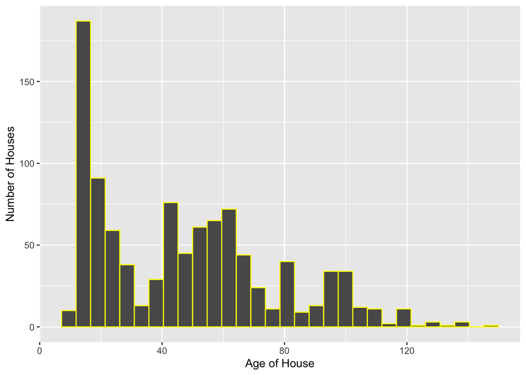

```r
# type your code for Question 1 here, and Knit

ggplot(ames_train, aes(2020-Year.Built),gpars=list(col="yellow")) + geom_histogram(bins=30,col="yellow") + xlab("Age of House") + ylab("Number of Houses")
```

The data is right-skewed.From the histogram we can see that most of houses in the data set were built less than 50 years.The ames_train data does not include any houses built after 2010. * * *

# 2

The mantra in real estate is “Location, Location, Location!” Make a graphical display that relates a home price to its neighborhood in Ames, Iowa. Which summary statistics are most appropriate to use for determining the most expensive, least expensive, and most heterogeneous (having the most variation in housing price) neighborhoods? Report which neighborhoods these are based on the summary statistics of your choice. Report the value of your chosen summary statistics for these neighborhoods.

```r
# type your code for Question 2 here, and Knit
demo_761 <- subset(ames_train,ames_train$Neighborhood=="IDOTRR")
demo_762 <- subset(ames_train,ames_train$Neighborhood=="NAmes")
demo_763 <- subset(ames_train,ames_train$Neighborhood=="NWAmes")
demo_764 <- subset(ames_train,ames_train$Neighborhood=="SWISU")
demo_761
```

```
## # A tibble: 35 x 81
##       PID  area  price MS.SubClass MS.Zoning Lot.Frontage Lot.Area Street Alley
##     <int> <int>  <int>       <int> <fct>            <int>    <int> <fct>  <fct>
##  1 9.11e8  1001 124900          30 C (all)             60     6060 Pave   <NA>
##  2 9.10e8   672  72000          30 RM                  61     8534 Pave   <NA>
##  3 9.03e8  1355 127000          70 RM                  60     6882 Pave   <NA>
##  4 9.11e8  1049  80900          50 C (all)             52     5150 Pave   <NA>
##  5 9.11e8  1396 115000         190 C (all)             50     9000 Pave   <NA>
##  6 9.10e8  1154 125500          50 RM                  40     5436 Pave   <NA>
##  7 9.10e8   641  85000          30 RM                  50     7030 Pave   <NA>
##  8 9.03e8  1484  50000          50 RM                  60    10320 Pave   Grvl
##  9 9.10e8   816  75200          30 RM                  46     3672 Pave   <NA>
## 10 9.03e8  1108 139400          45 RM                  57     7449 Pave   Grvl
## # … with 25 more rows, and 72 more variables: Lot.Shape <fct>,
## #   Land.Contour <fct>, Utilities <fct>, Lot.Config <fct>, Land.Slope <fct>,
## #   Neighborhood <fct>, Condition.1 <fct>, Condition.2 <fct>, Bldg.Type <fct>,
## #   House.Style <fct>, Overall.Qual <int>, Overall.Cond <int>,
## #   Year.Built <int>, Year.Remod.Add <int>, Roof.Style <fct>, Roof.Matl <fct>,
## #   Exterior.1st <fct>, Exterior.2nd <fct>, Mas.Vnr.Type <fct>,
## #   Mas.Vnr.Area <int>, Exter.Qual <fct>, Exter.Cond <fct>, Foundation <fct>,
## #   Bsmt.Qual <fct>, Bsmt.Cond <fct>, Bsmt.Exposure <fct>,
## #   BsmtFin.Type.1 <fct>, BsmtFin.SF.1 <int>, BsmtFin.Type.2 <fct>,
## #   BsmtFin.SF.2 <int>, Bsmt.Unf.SF <int>, Total.Bsmt.SF <int>, Heating <fct>,
## #   Heating.QC <fct>, Central.Air <fct>, Electrical <fct>, X1st.Flr.SF <int>,
## #   X2nd.Flr.SF <int>, Low.Qual.Fin.SF <int>, Bsmt.Full.Bath <int>,
## #   Bsmt.Half.Bath <int>, Full.Bath <int>, Half.Bath <int>,
## #   Bedroom.AbvGr <int>, Kitchen.AbvGr <int>, Kitchen.Qual <fct>,
## #   TotRms.AbvGrd <int>, Functional <fct>, Fireplaces <int>,
## #   Fireplace.Qu <fct>, Garage.Type <fct>, Garage.Yr.Blt <int>,
## #   Garage.Finish <fct>, Garage.Cars <int>, Garage.Area <int>,
## #   Garage.Qual <fct>, Garage.Cond <fct>, Paved.Drive <fct>,
## #   Wood.Deck.SF <int>, Open.Porch.SF <int>, Enclosed.Porch <int>,
## #   X3Ssn.Porch <int>, Screen.Porch <int>, Pool.Area <int>, Pool.QC <fct>,
## #   Fence <fct>, Misc.Feature <fct>, Misc.Val <int>, Mo.Sold <int>,
## #   Yr.Sold <int>, Sale.Type <fct>, Sale.Condition <fct>
```

```r
demo_762
```

```
## # A tibble: 155 x 81
##       PID  area  price MS.SubClass MS.Zoning Lot.Frontage Lot.Area Street Alley
##     <int> <int>  <int>       <int> <fct>            <int>    <int> <fct>  <fct>
##  1 5.35e8  1394 159000          20 RL                  NA     9500 Pave   <NA>
##  2 5.35e8  1269 155000          20 RL                  70     7931 Pave   <NA>
##  3 5.27e8   988 129250          20 RL                  65     7150 Pave   <NA>
##  4 5.35e8  1312 186000          20 RL                  76    11355 Pave   <NA>
##  5 5.34e8  1248 151500          20 RL                  80    10800 Pave   <NA>
##  6 5.35e8  1256 159000          20 RL                  80     8000 Pave   <NA>
##  7 5.27e8   936 111900          20 RL                  68    10295 Pave   <NA>
##  8 5.35e8  1370 148000          80 RL                 125    10000 Pave   <NA>
##  9 5.35e8   925  99000          20 RL                  70     7000 Pave   <NA>
## 10 5.35e8  1431 165000          80 RL                 101     9150 Pave   <NA>
## # … with 145 more rows, and 72 more variables: Lot.Shape <fct>,
## #   Land.Contour <fct>, Utilities <fct>, Lot.Config <fct>, Land.Slope <fct>,
## #   Neighborhood <fct>, Condition.1 <fct>, Condition.2 <fct>, Bldg.Type <fct>,
## #   House.Style <fct>, Overall.Qual <int>, Overall.Cond <int>,
## #   Year.Built <int>, Year.Remod.Add <int>, Roof.Style <fct>, Roof.Matl <fct>,
## #   Exterior.1st <fct>, Exterior.2nd <fct>, Mas.Vnr.Type <fct>,
## #   Mas.Vnr.Area <int>, Exter.Qual <fct>, Exter.Cond <fct>, Foundation <fct>,
## #   Bsmt.Qual <fct>, Bsmt.Cond <fct>, Bsmt.Exposure <fct>,
## #   BsmtFin.Type.1 <fct>, BsmtFin.SF.1 <int>, BsmtFin.Type.2 <fct>,
## #   BsmtFin.SF.2 <int>, Bsmt.Unf.SF <int>, Total.Bsmt.SF <int>, Heating <fct>,
## #   Heating.QC <fct>, Central.Air <fct>, Electrical <fct>, X1st.Flr.SF <int>,
## #   X2nd.Flr.SF <int>, Low.Qual.Fin.SF <int>, Bsmt.Full.Bath <int>,
## #   Bsmt.Half.Bath <int>, Full.Bath <int>, Half.Bath <int>,
## #   Bedroom.AbvGr <int>, Kitchen.AbvGr <int>, Kitchen.Qual <fct>,
## #   TotRms.AbvGrd <int>, Functional <fct>, Fireplaces <int>,
## #   Fireplace.Qu <fct>, Garage.Type <fct>, Garage.Yr.Blt <int>,
## #   Garage.Finish <fct>, Garage.Cars <int>, Garage.Area <int>,
## #   Garage.Qual <fct>, Garage.Cond <fct>, Paved.Drive <fct>,
## #   Wood.Deck.SF <int>, Open.Porch.SF <int>, Enclosed.Porch <int>,
## #   X3Ssn.Porch <int>, Screen.Porch <int>, Pool.Area <int>, Pool.QC <fct>,
## #   Fence <fct>, Misc.Feature <fct>, Misc.Val <int>, Mo.Sold <int>,
## #   Yr.Sold <int>, Sale.Type <fct>, Sale.Condition <fct>
```

```r
demo_763
```

```
## # A tibble: 41 x 81
##       PID  area  price MS.SubClass MS.Zoning Lot.Frontage Lot.Area Street Alley
##     <int> <int>  <int>       <int> <fct>            <int>    <int> <fct>  <fct>
##  1 5.34e8  1665 227000          60 RL                  70     8400 Pave   <NA>
##  2 5.34e8  1610 205000          20 RL                  NA    10603 Pave   <NA>
##  3 5.34e8  2090 200000          60 RL                  NA    10382 Pave   <NA>
##  4 5.27e8  2030 195000          60 RL                  NA    12046 Pave   <NA>
##  5 5.27e8  1868 178000          80 RL                  78    12090 Pave   <NA>
##  6 5.27e8  2044 185000          60 RL                  80    10400 Pave   <NA>
##  7 5.34e8  1790 165150          60 RL                  80    10400 Pave   <NA>
##  8 5.27e8  2872 272000          60 RL                  NA    12227 Pave   <NA>
##  9 5.27e8  1411  82500          20 RL                  85    11900 Pave   <NA>
## 10 5.27e8  2353 260000          60 RL                  94    13005 Pave   <NA>
## # … with 31 more rows, and 72 more variables: Lot.Shape <fct>,
## #   Land.Contour <fct>, Utilities <fct>, Lot.Config <fct>, Land.Slope <fct>,
## #   Neighborhood <fct>, Condition.1 <fct>, Condition.2 <fct>, Bldg.Type <fct>,
## #   House.Style <fct>, Overall.Qual <int>, Overall.Cond <int>,
## #   Year.Built <int>, Year.Remod.Add <int>, Roof.Style <fct>, Roof.Matl <fct>,
## #   Exterior.1st <fct>, Exterior.2nd <fct>, Mas.Vnr.Type <fct>,
## #   Mas.Vnr.Area <int>, Exter.Qual <fct>, Exter.Cond <fct>, Foundation <fct>,
## #   Bsmt.Qual <fct>, Bsmt.Cond <fct>, Bsmt.Exposure <fct>,
## #   BsmtFin.Type.1 <fct>, BsmtFin.SF.1 <int>, BsmtFin.Type.2 <fct>,
## #   BsmtFin.SF.2 <int>, Bsmt.Unf.SF <int>, Total.Bsmt.SF <int>, Heating <fct>,
## #   Heating.QC <fct>, Central.Air <fct>, Electrical <fct>, X1st.Flr.SF <int>,
## #   X2nd.Flr.SF <int>, Low.Qual.Fin.SF <int>, Bsmt.Full.Bath <int>,
## #   Bsmt.Half.Bath <int>, Full.Bath <int>, Half.Bath <int>,
## #   Bedroom.AbvGr <int>, Kitchen.AbvGr <int>, Kitchen.Qual <fct>,
## #   TotRms.AbvGrd <int>, Functional <fct>, Fireplaces <int>,
## #   Fireplace.Qu <fct>, Garage.Type <fct>, Garage.Yr.Blt <int>,
## #   Garage.Finish <fct>, Garage.Cars <int>, Garage.Area <int>,
## #   Garage.Qual <fct>, Garage.Cond <fct>, Paved.Drive <fct>,
## #   Wood.Deck.SF <int>, Open.Porch.SF <int>, Enclosed.Porch <int>,
## #   X3Ssn.Porch <int>, Screen.Porch <int>, Pool.Area <int>, Pool.QC <fct>,
## #   Fence <fct>, Misc.Feature <fct>, Misc.Val <int>, Mo.Sold <int>,
## #   Yr.Sold <int>, Sale.Type <fct>, Sale.Condition <fct>
```

```r
demo_764
```

```
## # A tibble: 12 x 81
##       PID  area  price MS.SubClass MS.Zoning Lot.Frontage Lot.Area Street Alley
##     <int> <int>  <int>       <int> <fct>            <int>    <int> <fct>  <fct>
##  1 9.09e8   856 126000          30 RL                  NA     7890 Pave   <NA>
##  2 9.09e8  2592 150000          90 RL                  60    10890 Pave   <NA>
##  3 9.09e8  2447 169000          50 RL                  50     9638 Pave   <NA>
##  4 9.09e8  1522 102000          50 RL                  60     6000 Pave   <NA>
##  5 9.09e8   790  91000          30 RL                  52     6292 Pave   <NA>
##  6 9.09e8  1465 131000          50 RL                  84    10164 Pave   <NA>
##  7 9.09e8  1551 137000          50 RL                  60    10890 Pave   <NA>
##  8 9.09e8  1510 149000          70 RL                  69     4899 Pave   <NA>
##  9 9.09e8  1520 159434          50 RH                  55     4500 Pave   Pave
## 10 9.09e8  1647 128000          70 RL                  66     6858 Pave   <NA>
## 11 9.09e8  1477 145000          50 RL                  52     6292 Pave   <NA>
## 12 9.04e8   879  80000          30 RL                  50     5220 Pave   <NA>
## # … with 72 more variables: Lot.Shape <fct>, Land.Contour <fct>,
## #   Utilities <fct>, Lot.Config <fct>, Land.Slope <fct>, Neighborhood <fct>,
## #   Condition.1 <fct>, Condition.2 <fct>, Bldg.Type <fct>, House.Style <fct>,
## #   Overall.Qual <int>, Overall.Cond <int>, Year.Built <int>,
## #   Year.Remod.Add <int>, Roof.Style <fct>, Roof.Matl <fct>,
## #   Exterior.1st <fct>, Exterior.2nd <fct>, Mas.Vnr.Type <fct>,
## #   Mas.Vnr.Area <int>, Exter.Qual <fct>, Exter.Cond <fct>, Foundation <fct>,
## #   Bsmt.Qual <fct>, Bsmt.Cond <fct>, Bsmt.Exposure <fct>,
## #   BsmtFin.Type.1 <fct>, BsmtFin.SF.1 <int>, BsmtFin.Type.2 <fct>,
## #   BsmtFin.SF.2 <int>, Bsmt.Unf.SF <int>, Total.Bsmt.SF <int>, Heating <fct>,
## #   Heating.QC <fct>, Central.Air <fct>, Electrical <fct>, X1st.Flr.SF <int>,
## #   X2nd.Flr.SF <int>, Low.Qual.Fin.SF <int>, Bsmt.Full.Bath <int>,
## #   Bsmt.Half.Bath <int>, Full.Bath <int>, Half.Bath <int>,
## #   Bedroom.AbvGr <int>, Kitchen.AbvGr <int>, Kitchen.Qual <fct>,
## #   TotRms.AbvGrd <int>, Functional <fct>, Fireplaces <int>,
## #   Fireplace.Qu <fct>, Garage.Type <fct>, Garage.Yr.Blt <int>,
## #   Garage.Finish <fct>, Garage.Cars <int>, Garage.Area <int>,
## #   Garage.Qual <fct>, Garage.Cond <fct>, Paved.Drive <fct>,
## #   Wood.Deck.SF <int>, Open.Porch.SF <int>, Enclosed.Porch <int>,
## #   X3Ssn.Porch <int>, Screen.Porch <int>, Pool.Area <int>, Pool.QC <fct>,
## #   Fence <fct>, Misc.Feature <fct>, Misc.Val <int>, Mo.Sold <int>,
## #   Yr.Sold <int>, Sale.Type <fct>, Sale.Condition <fct>
```

```r
# We can see that there are three different dataframes respective represent "Iowa DOT and Rail Road","North Ames","Northwest Ames"
summary(demo_761$price)
```

```
##    Min. 1st Qu.  Median    Mean 3rd Qu.    Max.
##   34900   76600   99500   97621  125500  150909
```

```r
summary(demo_762$price)
```

```
##    Min. 1st Qu.  Median    Mean 3rd Qu.    Max.
##   76500  125950  139900  141356  153000  277500
```

```r
summary(demo_763$price)
```

```
##    Min. 1st Qu.  Median    Mean 3rd Qu.    Max.
##   82500  167900  185000  194094  227000  278000
```

```r
summary(demo_764$price)
```

```
##    Min. 1st Qu.  Median    Mean 3rd Qu.    Max.
##   80000  120000  134000  130620  149250  169000
```

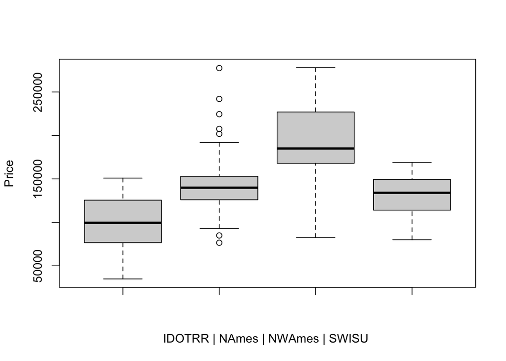

```r
# We can see that there are more vivid to decide which is the most expensive or the least expensive neighborhood in the boxplot.
boxplot(demo_761$price,demo_762$price,demo_763$price,demo_764$price,ylab= "Price",xlab = "IDOTRR | NAmes | NWAmes | SWISU ")
```

```r
var(demo_761$price)
```

```
## [1] 994168913
```

```r
var(demo_762$price)
```

```
## [1] 743542382
```

```r
var(demo_763$price)
```

```
## [1] 1709037274
```

```r
var(demo_764$price)
```

```
## [1] 749432272
```

# 3

Which variable has the largest number of missing values? Explain why it makes sense that there are so many missing values for this variable.

```r
# type your code for Question 3 here, and Knit
summary(ames_train)
```

```
##       PID                 area          price         MS.SubClass
##  Min.   :5.263e+08   Min.   : 334   Min.   : 12789   Min.   : 20.00
##  1st Qu.:5.285e+08   1st Qu.:1092   1st Qu.:129762   1st Qu.: 20.00
##  Median :5.354e+08   Median :1411   Median :159467   Median : 50.00
##  Mean   :7.059e+08   Mean   :1477   Mean   :181190   Mean   : 57.15
##  3rd Qu.:9.071e+08   3rd Qu.:1743   3rd Qu.:213000   3rd Qu.: 70.00
##  Max.   :1.007e+09   Max.   :4676   Max.   :615000   Max.   :190.00
##
##    MS.Zoning    Lot.Frontage       Lot.Area       Street     Alley
##  A (agr):  0   Min.   : 21.00   Min.   :  1470   Grvl:  3   Grvl: 33
##  C (all):  9   1st Qu.: 57.00   1st Qu.:  7314   Pave:997   Pave: 34
##  FV     : 56   Median : 69.00   Median :  9317              NA's:933
##  I (all):  1   Mean   : 69.21   Mean   : 10352
##  RH     :  7   3rd Qu.: 80.00   3rd Qu.: 11650
##  RL     :772   Max.   :313.00   Max.   :215245
##  RM     :155   NA's   :167
##  Lot.Shape Land.Contour  Utilities      Lot.Config  Land.Slope  Neighborhood
##  IR1:338   Bnk: 33      AllPub:1000   Corner :173   Gtl:962    NAmes  :155
##  IR2: 30   HLS: 38      NoSeWa:   0   CulDSac: 76   Mod: 33    CollgCr: 85
##  IR3:  3   Low: 20      NoSewr:   0   FR2    : 36   Sev:  5    Somerst: 74
##  Reg:629   Lvl:909                    FR3    :  5              OldTown: 71
##                                       Inside :710              Sawyer : 61
##                                                                Edwards: 60
##                                                                (Other):494
##   Condition.1   Condition.2   Bldg.Type    House.Style   Overall.Qual
##  Norm   :875   Norm   :988   1Fam  :823   1Story :521   Min.   : 1.000
##  Feedr  : 53   Feedr  :  6   2fmCon: 20   2Story :286   1st Qu.: 5.000
##  Artery : 23   Artery :  2   Duplex: 35   1.5Fin : 98   Median : 6.000
##  RRAn   : 14   PosN   :  2   Twnhs : 38   SLvl   : 41   Mean   : 6.095
##  PosN   : 11   PosA   :  1   TwnhsE: 84   SFoyer : 36   3rd Qu.: 7.000
##  RRAe   : 11   RRNn   :  1                2.5Unf : 10   Max.   :10.000
##  (Other): 13   (Other):  0                (Other):  8
##   Overall.Cond     Year.Built   Year.Remod.Add   Roof.Style    Roof.Matl
##  Min.   :1.000   Min.   :1872   Min.   :1950   Flat   :  9   CompShg:984
##  1st Qu.:5.000   1st Qu.:1955   1st Qu.:1966   Gable  :775   Tar&Grv: 11
##  Median :5.000   Median :1975   Median :1992   Gambrel:  8   WdShake:  2
##  Mean   :5.559   Mean   :1972   Mean   :1984   Hip    :204   WdShngl:  2
##  3rd Qu.:6.000   3rd Qu.:2001   3rd Qu.:2004   Mansard:  4   Metal  :  1
##  Max.   :9.000   Max.   :2010   Max.   :2010   Shed   :  0   ClyTile:  0
##                                                              (Other):  0
```

[output cut: 81 more lines]

```
##  Min.   :  0.000   Ex  :  1   GdPrv: 43   Elev:  0     Min.   :    0.00
##  1st Qu.:  0.000   Fa  :  1   GdWo : 37   Gar2:  2     1st Qu.:    0.00
##  Median :  0.000   Gd  :  1   MnPrv:120   Othr:  1     Median :    0.00
##  Mean   :  1.463   TA  :  0   MnWw :  2   Shed: 25     Mean   :   45.81
##  3rd Qu.:  0.000   NA's:997   NA's :798   TenC:  1     3rd Qu.:    0.00
##  Max.   :800.000                          NA's:971     Max.   :15500.00
##
##     Mo.Sold          Yr.Sold       Sale.Type   Sale.Condition
##  Min.   : 1.000   Min.   :2006   WD     :863   Abnorml: 61
##  1st Qu.: 4.000   1st Qu.:2007   New    : 79   AdjLand:  2
##  Median : 6.000   Median :2008   COD    : 27   Alloca :  4
##  Mean   : 6.243   Mean   :2008   ConLD  :  7   Family : 17
##  3rd Qu.: 8.000   3rd Qu.:2009   ConLw  :  6   Normal :834
##  Max.   :12.000   Max.   :2010   Con    :  5   Partial: 82
##                                  (Other): 13
```

We can see that missing values using “summary” function.Apparently Pool quality has the largest number of missing values.It is sensible because the most of houses do not have pool. * * *

# 4

We want to predict the natural log of the home prices. Candidate explanatory variables are lot size in square feet (Lot.Area), slope of property (Land.Slope), original construction date (Year.Built), remodel date (Year.Remod.Add), and the number of bedrooms above grade (Bedroom.AbvGr). Pick a model selection or model averaging method covered in the Specialization, and describe how this method works. Then, use this method to find the best multiple regression model for predicting the natural log of the home prices.

```r
# type your code for Question 4 here, and Knit
library(BAS)
demo_767 <- bas.lm(log(price) ~ Lot.Area + Land.Slope + Year.Built + Year.Remod.Add + Bedroom.AbvGr, data = ames_train, prior = "BIC", modelprior = uniform())
summary(demo_767)
```

```
##                P(B != 0 | Y)    model 1       model 2      model 3
## Intercept          1.0000000     1.0000     1.0000000     1.000000
## Lot.Area           1.0000000     1.0000     1.0000000     1.000000
## Land.SlopeMod      0.6323994     1.0000     0.0000000     1.000000
## Land.SlopeSev      0.7923033     1.0000     1.0000000     0.000000
## Year.Built         1.0000000     1.0000     1.0000000     1.000000
## Year.Remod.Add     1.0000000     1.0000     1.0000000     1.000000
## Bedroom.AbvGr      1.0000000     1.0000     1.0000000     1.000000
## BF                        NA     1.0000     0.6674353     0.330911
## PostProbs                 NA     0.4752     0.3171000     0.157200
## R2                        NA     0.5625     0.5591000     0.558500
## dim                       NA     7.0000     6.0000000     6.000000
## logmarg                   NA -2198.1673 -2198.5716571 -2199.273250
##                      model 4       model 5
## Intercept          1.0000000  1.000000e+00
## Lot.Area           1.0000000  1.000000e+00
## Land.SlopeMod      0.0000000  0.000000e+00
## Land.SlopeSev      0.0000000  1.000000e+00
## Year.Built         1.0000000  1.000000e+00
## Year.Remod.Add     1.0000000  1.000000e+00
## Bedroom.AbvGr      1.0000000  0.000000e+00
## BF                 0.1061955  1.578929e-12
## PostProbs          0.0505000  0.000000e+00
## R2                 0.5544000  5.316000e-01
## dim                5.0000000  5.000000e+00
## logmarg        -2200.4098178 -2.225342e+03
```

BAS provides several algorithms to sample from posterior distributions of models for use in Bayesian Model Averaging or Bayesian variable selection. Because this approach allow us to average multiple models instead of just picking one model.the final model looks like this: log_price ~ Lot.Area + Land.Slope + Year.Built + Year.Remod.Add + Bedroom.AbvGr. * * *

# 5

Which home has the largest squared residual in the previous analysis (Question 4)? Looking at all the variables in the data set, can you explain why this home stands out from the rest (what factors contribute to the high squared residual and why are those factors relevant)?

```r
# type your code for Question 5 here, and Knit
demo_766 <- lm(log(price) ~ Lot.Area + Land.Slope + Year.Built + Year.Remod.Add + Bedroom.AbvGr, data = ames_train)
ames_log <- ames_train %>%
  mutate(sqrresid = resid(demo_766) ** 2) %>%
  arrange(desc(sqrresid))
head(ames_log, n=1)
```

```
## # A tibble: 1 x 82
##      PID  area price MS.SubClass MS.Zoning Lot.Frontage Lot.Area Street Alley
##    <int> <int> <int>       <int> <fct>            <int>    <int> <fct>  <fct>
## 1 9.02e8   832 12789          30 RM                  68     9656 Pave   <NA>
## # … with 73 more variables: Lot.Shape <fct>, Land.Contour <fct>,
## #   Utilities <fct>, Lot.Config <fct>, Land.Slope <fct>, Neighborhood <fct>,
## #   Condition.1 <fct>, Condition.2 <fct>, Bldg.Type <fct>, House.Style <fct>,
## #   Overall.Qual <int>, Overall.Cond <int>, Year.Built <int>,
## #   Year.Remod.Add <int>, Roof.Style <fct>, Roof.Matl <fct>,
## #   Exterior.1st <fct>, Exterior.2nd <fct>, Mas.Vnr.Type <fct>,
## #   Mas.Vnr.Area <int>, Exter.Qual <fct>, Exter.Cond <fct>, Foundation <fct>,
## #   Bsmt.Qual <fct>, Bsmt.Cond <fct>, Bsmt.Exposure <fct>,
## #   BsmtFin.Type.1 <fct>, BsmtFin.SF.1 <int>, BsmtFin.Type.2 <fct>,
## #   BsmtFin.SF.2 <int>, Bsmt.Unf.SF <int>, Total.Bsmt.SF <int>, Heating <fct>,
## #   Heating.QC <fct>, Central.Air <fct>, Electrical <fct>, X1st.Flr.SF <int>,
## #   X2nd.Flr.SF <int>, Low.Qual.Fin.SF <int>, Bsmt.Full.Bath <int>,
## #   Bsmt.Half.Bath <int>, Full.Bath <int>, Half.Bath <int>,
## #   Bedroom.AbvGr <int>, Kitchen.AbvGr <int>, Kitchen.Qual <fct>,
## #   TotRms.AbvGrd <int>, Functional <fct>, Fireplaces <int>,
## #   Fireplace.Qu <fct>, Garage.Type <fct>, Garage.Yr.Blt <int>,
## #   Garage.Finish <fct>, Garage.Cars <int>, Garage.Area <int>,
## #   Garage.Qual <fct>, Garage.Cond <fct>, Paved.Drive <fct>,
## #   Wood.Deck.SF <int>, Open.Porch.SF <int>, Enclosed.Porch <int>,
## #   X3Ssn.Porch <int>, Screen.Porch <int>, Pool.Area <int>, Pool.QC <fct>,
## #   Fence <fct>, Misc.Feature <fct>, Misc.Val <int>, Mo.Sold <int>,
## #   Yr.Sold <int>, Sale.Type <fct>, Sale.Condition <fct>, sqrresid <dbl>
```

We can see that the largest squared residual in the previous analysis is home with PID:902207130. It has been bulit for more than 100 years, besides with the lowest price in the whole houses. * * *

# 6

Use the same model selection method you chose in Question 4 to again find the best multiple regression model to predict the natural log of home prices, but this time **replacing Lot.Area with log(Lot.Area)**. Do you arrive at a model including the same set of predictors?

```r
# type your code for Question 6 here, and Knit
demo_771 <- bas.lm(log(price) ~ log(Lot.Area) + Land.Slope + Year.Built + Year.Remod.Add + Bedroom.AbvGr, data = ames_train, prior = "BIC", modelprior = uniform())
summary(demo_771)
```

```
##                P(B != 0 | Y)    model 1       model 2       model 3
## Intercept         1.00000000     1.0000     1.0000000  1.000000e+00
## log(Lot.Area)     1.00000000     1.0000     1.0000000  1.000000e+00
## Land.SlopeMod     0.39325522     0.0000     1.0000000  0.000000e+00
## Land.SlopeSev     0.03645331     0.0000     0.0000000  1.000000e+00
## Year.Built        1.00000000     1.0000     1.0000000  1.000000e+00
## Year.Remod.Add    1.00000000     1.0000     1.0000000  1.000000e+00
## Bedroom.AbvGr     0.99998941     1.0000     1.0000000  1.000000e+00
## BF                        NA     1.0000     0.6494644  3.866294e-02
## PostProbs                 NA     0.5842     0.3794000  2.260000e-02
## R2                        NA     0.6031     0.6055000  6.032000e-01
## dim                       NA     5.0000     6.0000000  6.000000e+00
## logmarg                   NA -2142.5652 -2142.9968106 -2.145818e+03
##                      model 4       model 5
## Intercept       1.000000e+00  1.000000e+00
## log(Lot.Area)   1.000000e+00  1.000000e+00
## Land.SlopeMod   1.000000e+00  0.000000e+00
## Land.SlopeSev   1.000000e+00  0.000000e+00
## Year.Built      1.000000e+00  1.000000e+00
## Year.Remod.Add  1.000000e+00  1.000000e+00
## Bedroom.AbvGr   1.000000e+00  0.000000e+00
## BF              2.374021e-02  1.412793e-05
## PostProbs       1.390000e-02  0.000000e+00
## R2              6.056000e-01  5.913000e-01
## dim             7.000000e+00  4.000000e+00
## logmarg        -2.146306e+03 -2.153733e+03
```

Do you think it is better to log transform Lot.Area, in terms of assumptions for linear regression? Make graphs of the predicted values of log home price versus the true values of log home price for the regression models selected for Lot.Area and log(Lot.Area). Referencing these two plots, provide a written support that includes a quantitative justification for your answer in the first part of question 7.

```r
# type your code for Question 7 here, and Knit
library(dplyr)
library(base)
library(generics)
```

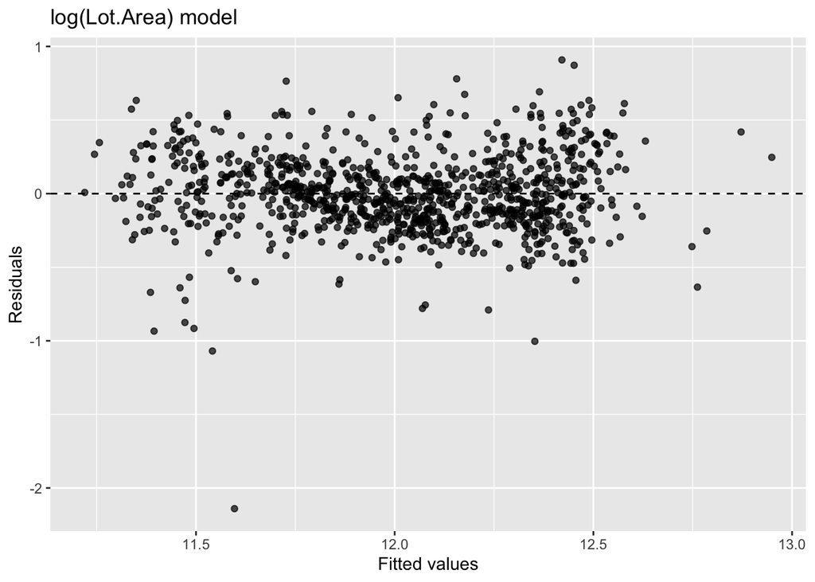

```r
demo_765 <- lm(log(price) ~ log(Lot.Area) + Land.Slope + Year.Built + Year.Remod.Add + Bedroom.AbvGr, data = ames_train)
ggplot(data = demo_765, aes(x = .fitted, y = .resid)) +
  geom_point(alpha = 0.7) +
  geom_hline(yintercept = 0, linetype = "dashed") +
  labs(title = "log(Lot.Area) model", x = "Fitted values", y = "Residuals")
```

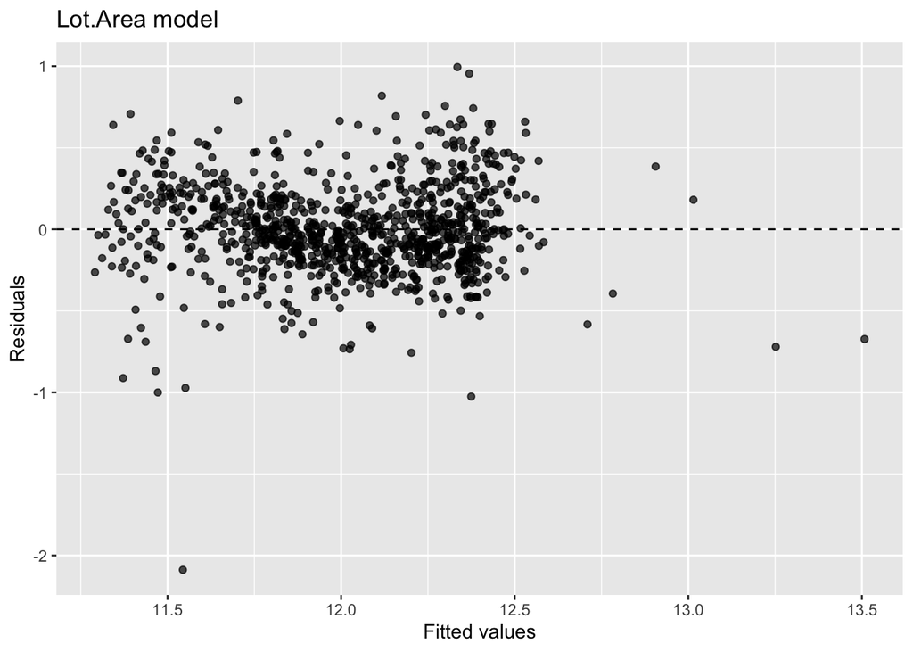

```r
ggplot(data = demo_766, aes(x = .fitted, y = .resid)) +
  geom_point(alpha = 0.7) +
  geom_hline(yintercept = 0, linetype = "dashed") +
  labs(title = "Lot.Area model", x = "Fitted values", y = "Residuals")
```

```r
BIC(demo_765,demo_766)
```

```
##          df      BIC
## demo_765  8 229.6411
## demo_766  8 333.3642
```

The plots above illustrate that the residuals are more evenly distributed around the fitted lines in the model including log(Lot.Area) than for the model including Lot.Area. With “BIC” function, it was also confirmed in a quantitative justification that model with the log(Lot.Area) is better. * * * ###